# Informe PEC1

Irati Bastero

2024-11-06

## Objetivos del estudio.

El objetivo de este PEC es realizar un análisis de datos ómicos (metabolómicos en este caso) y familiarizarse con los conceptos y herramientas trabajados hasta el momento en la asignatura. Los datos ómicos son una gran fuente de información que puede resultar muy útil pero difícil de explorar al mismo tiempo. Es necesario filtrar y examinar esta información empleando herramientas que faciliten el trabajo, como son los contenedores de datos ómicos, las herramientas de exploración de datos o los repositorios como github.

## Materiales y Métodos

Para esta primera prueba de evaluación continua, he seleccionado el dataset de metabolómica “GastricCancer_NMR” descargado del repositorio de github proporcionado para la PEC.

Este dataset proviene de un estudio que tenía como objetivo identificar si el cáncer gástrico (CG) tiene un perfil metabolómico urinario único en comparación con la enfermedad gástrica benigna (BN) y los pacientes sanos (HE). Para ello se analizó la orina de 43 pacientes con CG, 40 con BN y 40 con HE mediante espectroscopia de resonancia magnética nuclear 1H (1H-NMR), generando 77 metabolitos reproducibles (QC-RSD <25%). La información sobre el proyecto puede encontrarse aquí: [1H-NMR urinary metabolomic profiling for diagnosis of gastric cancer](https://www.metabolomicsworkbench.org/data/DRCCMetadata.php?Mode=Project&ProjectID=PR000699)

Las herramientas con las que he trabajado han sido Bioconductor y github. Me he basado también en el tutorial [Basic Metabolomics Data Analysis Workflow](https://cimcb.github.io/MetabWorkflowTutorial/Tutorial1.html) para el análisis exploratorio de datos.

## Resultados

### Preparación de los datos

En primer lugar, he instalado `SummarizedExperiment`desde Bioconductor

```r
library(SummarizedExperiment)
```

Después he accedido al archivo xlsx:

```r
library(readxl)

file <- "GastricCancer_NMR.xlsx"
```

El fichero xlsx contiene dos hojas, “Data” y “Peak”. A continuación, he cargado los datos de la hoja “Data” y he extraído las columnas con información sobre los tipos de muestra:

```r
# Cargar datos de la hoja "Data"
data <- read_excel(file, sheet = "Data", na = "NA")

# Extraer las columnas de `colData`
colData <- data[, c("SampleID", "SampleType", "Class")]

# Convertir `colData` a `data.frame`
colData <- DataFrame(colData)

# Usar `SampleID` como nombres de fila
rownames(colData) <- colData$SampleID

head(colData)
```

```
## DataFrame with 6 rows and 3 columns
##             SampleID  SampleType       Class
##          <character> <character> <character>
## sample_1    sample_1          QC          QC
## sample_2    sample_2      Sample          GC
## sample_3    sample_3      Sample          BN
## sample_4    sample_4      Sample          HE
## sample_5    sample_5      Sample          GC
## sample_6    sample_6      Sample          BN
```

En este `Dataframe`, la columna `SampleType` indica si la muestra es una muestra de control de calidad o una muestra de estudio. Por otro lado, la columna `Class` indica el resultado clínico observado para ese individuo: GC = Cáncer gástrico , BN = Tumor benigno , HE = Control sano.

A partir de la hoja “Data”, también he creado una matriz con los datos cuantitativos:

```r
# Crear la matriz de datos cuantitativos, seleccionando solo las columnas `M5` a `M149` de la hoja "Data"
data_matrix_counts <- data[, 5:ncol(data)]

# Convertir a matriz para asignar nombres de fila
data_matrix_counts <- as.matrix(data_matrix_counts)

# Asignar nombres de fila
rownames(data_matrix_counts) <- data$SampleID

head(data_matrix_counts)
```

```
##             M1      M2    M3   M4    M5    M6    M7    M8    M9   M10    M11
## sample_1  90.1   491.6 202.9 35.0 164.2  19.7  41.0  46.5  17.3 106.8   61.7
## sample_2  43.0   525.7 130.2   NA 694.5 114.5  37.9 125.7  57.8    NA  490.6
## sample_3 214.3 10703.2 104.7 46.8 483.4 152.3 110.1  85.1 238.3  48.0 2441.2
## sample_4  31.6    59.7  86.4 14.0  88.6  10.3 170.3  23.9    NA    NA  140.7
## sample_5  81.9   258.7 315.1  8.7 243.2  18.4 349.4  61.1  12.2  72.9   48.7
## sample_6 196.9   128.2 862.5 18.7 200.1   4.7  37.3 243.7 293.3 113.1  103.7
##            M12   M13  M14   M15   M16  M17   M18   M19   M20   M21   M22   M23
## sample_1  75.3  79.7 35.3  28.8 245.9  5.8 122.2  90.9  47.0  49.0  37.2 422.0
## sample_2 203.4 330.8   NA 210.7 150.3 71.5 553.1 217.7 207.9 238.8 297.2 591.2
## sample_3 100.0 873.3 29.3  45.4 226.4 36.3 371.9  98.1 116.5  30.3  24.6 593.4
## sample_4  12.6  46.3 62.9  38.3  49.7  0.4  31.3  38.6  53.2  45.4   3.7 130.1
## sample_5  57.3 140.1 77.8  51.0  71.3 18.8 265.0  84.7  78.8 141.3  58.0 722.1
## sample_6 116.6  81.7 52.3  76.8 273.5 45.8 394.7  66.9  63.0 101.1  96.6 640.5
##            M24  M25  M26   M27    M28   M29  M30    M31   M32   M33   M34
## sample_1 155.1 21.4 16.5    NA   19.9  65.0 22.0   18.9  97.8 274.1  26.3
## sample_2 446.4 28.3 47.9 126.8   12.9 291.9 58.5 1336.6 621.2 776.7 324.5
## sample_3 232.6 35.1 26.8  78.4 3772.3 144.3 52.8    0.2 360.1 532.3 507.0
## sample_4   1.6 26.6 10.3  22.8   14.5  25.5 11.2    4.8 111.6 133.4  37.3
## sample_5 174.7 58.9 65.9   2.8   15.3  63.5 38.1   11.2 233.6 328.4  79.4
## sample_6  74.8 29.1 20.3 185.5   55.9 157.6 88.8  112.0  76.4 297.9    NA
##             M35   M36   M37   M38   M39   M40  M41   M42  M43   M44    M45
## sample_1  110.8  13.0  33.7 352.3  34.7  33.8 69.9  47.7  7.9 119.1  631.6
## sample_2  282.8 154.3 403.3  11.7  66.1  50.9   NA 226.8 46.2  45.4 5354.5
## sample_3 3207.5 161.7  21.7 947.7 185.6 124.3 80.0 129.5 40.9  79.4 1230.8
## sample_4     NA  34.5  31.0  60.5  14.7  28.8 80.1  67.0 11.0  34.8 1679.3
## sample_5    7.1 305.9  12.2 327.2  23.3  87.3 84.7 116.2 40.7  38.4 2035.5
## sample_6     NA  17.4 141.4 362.5  52.9 100.6   NA 110.9 19.3   9.2 2578.0
##            M46   M47     M48   M49   M50   M51   M52    M53  M54     M55   M56
## sample_1 403.7  47.4  8029.5  91.3  98.1 372.1 148.2  562.4  0.3   102.6  74.1
## sample_2 109.3    NA 16744.8 775.4 563.5 520.6 306.7 1292.2  4.6   604.3 140.3
## sample_3 382.8    NA 12939.2 464.5 512.4    NA 197.6 6413.9 26.7    19.7 145.8
## sample_4   9.7  38.6  4562.6 112.2  67.6 263.2 134.8  130.6  1.0    36.2  44.7
## sample_5 278.7  99.2 12562.3 390.7 197.8 575.6 190.7  759.9  2.3    70.4 148.6
## sample_6   7.0 223.6  8484.2 107.0 128.8 229.6  90.3  689.4  0.4 12202.2 116.8
##             M57    M58    M59    M60    M61   M62     M63   M64    M65    M66
## sample_1  200.4  195.6  474.5  170.9  564.9 232.0   253.1 115.9  262.7 3104.5
## sample_2 1158.9 1631.4  590.9  798.6 1215.6 785.6  2965.9 490.2 1416.5 3168.2
## sample_3 9435.5 1155.3 6537.7 2813.2 3118.4    NA 12076.8 612.3 1798.1  689.4
## sample_4  141.6  159.8   74.6   38.7  264.4 195.5   511.6 309.8  156.9  632.1
```

[output cut: 43 more lines]

```
## sample_6 848.7 135.0  38.9 375.8 1392.6  850.6  75.9  964.9 102.5  76.5     NA
##             M135   M136   M137   M138   M139  M140   M141 M142   M143 M144
## sample_1  1106.9  107.6 2807.8  481.0   68.4 115.1   64.8 25.5  473.9 26.5
## sample_2  9079.2     NA  938.9 6084.5   75.3  84.2  357.1 16.1  455.5 29.5
## sample_3  1404.5 1564.3 1163.2  246.0 2460.4 993.5 1698.5 32.9   75.9 33.2
## sample_4   550.0   43.4  370.6  109.3   68.7  58.1   83.5 60.5  136.9 17.0
## sample_5  1494.7   85.8  984.0 1037.4   66.4  44.5   47.6 45.6 1441.7 35.2
## sample_6 19079.6  741.4 2916.5 1732.1  381.9 143.8  157.2 10.4  182.1 32.6
##           M145  M146  M147  M148  M149
## sample_1    NA   6.8 118.6 710.6 203.6
## sample_2  28.1  35.8 316.1 390.7 199.0
## sample_3 802.8 967.6 154.4  31.6 195.2
## sample_4  10.2  24.7  64.1  91.4  91.6
## sample_5   0.1  22.8 135.0 322.3 254.3
## sample_6 435.1 325.3 162.4 129.7 207.2
```

En esta matriz, cada fila describe una única muestra de orina, donde las columnas de M1 a M149 describen las concentraciones de metabolitos.

Por otro lado, he extraído los datos de la hoja “Peak” y lo he convertido en `dataframe`:

```r
# Cargar datos de la hoja "Peak"
row_metadata <- read_excel(file, sheet = "Peak", na = "NA")

# Asignar nombres de fila en `rowData` y convertir a `DataFrame`
rowData <- DataFrame(row_metadata)
rownames(rowData) <- row_metadata$Name

head(rowData)
```

```
## DataFrame with 6 rows and 5 columns
##          Idx        Name                  Label Perc_missing    QC_RSD
##    <numeric> <character>            <character>    <numeric> <numeric>
## M1         1          M1      1_3-Dimethylurate    11.428571  32.20800
## M2         2          M2 1_6-Anhydro-β-D-gluc..     0.714286  31.17803
## M3         3          M3   1_7-Dimethylxanthine     5.000000  34.99060
## M4         4          M4   1-Methylnicotinamide     8.571429  12.80420
## M5         5          M5         2-Aminoadipate     1.428571   9.37266
## M6         6          M6        2-Aminobutyrate     5.000000  46.97715
```

En el caso de este `DataFrame`, cada fila describe un único metabolito, donde: - `Idx` es un índice único de metabolito. - `Name` es la cabecera de columna correspondiente a este metabolito en la matriz de datos. - `Label` proporciona un nombre único para el metabolito (o un identificador uNNN) - La columna `Perc_missing` indica qué porcentaje de muestras no contienen una medición para este metabolito (datos que faltan). - Finalmente, la columna `QC_RSD` es una puntuación de calidad que representa la variación en las mediciones de este metabolito en todas las muestras.

Siguiendo con la prepración de los datos, para evitar desajustes de dimensión entre `data_matrix_counts` y `colData`, compruebo sus dimensiones:

```r
dim(data_matrix_counts)
```

```
## [1] 140 149
```

```r
dim(colData)
```

```
## [1] 140   3
```

Voy a transponer la matriz de datos para que `data_matrix_counts` tenga las muestras como columnas y las características como filas:

```r
data_matrix_counts <- t(data_matrix_counts)
```

Compruebo las dimensiones de nuevo:

```r
dim(data_matrix_counts)  # Ahora debería devolver (n_características, n_muestras)
```

```
## [1] 149 140
```

```r
dim(colData) # Debería devolver (n_muestras, n_metadatos)
```

```
## [1] 140   3
```

### Creación del contenedor del tipo `SummarizedExperiment`

Ahora que los datos están listos, voy a proceder a crear el contenedor `SummarizedExperiment` y a comprobar su estructura:

```r
library(SummarizedExperiment)

# Crear el objeto SummarizedExperiment
se <- SummarizedExperiment(assays = list(counts = data_matrix_counts), rowData = rowData, colData = colData)

# Comprobamos la estructura de SummarizedExperiment
se
```

```
## class: SummarizedExperiment
## dim: 149 140
## metadata(0):
## assays(1): counts
## rownames(149): M1 M2 ... M148 M149
## rowData names(5): Idx Name Label Perc_missing QC_RSD
## colnames(140): sample_1 sample_2 ... sample_139 sample_140
## colData names(3): SampleID SampleType Class
```

```r
class(se)
```

```
## [1] "SummarizedExperiment"
## attr(,"package")
## [1] "SummarizedExperiment"
```

Podemos acceder a los datos cuantitativos de las muestras:

```r
assays(se)$counts
```

[output not shown]

[output cut: 3095 more lines]

```
## M135     1134.4     5342.2      494.7      332.9      900.6
## M136       98.4      250.1         NA        9.0      109.6
## M137     2792.5      683.1       68.0      283.6     2757.8
## M138      451.8     3241.9      241.5      291.8      432.5
## M139        1.0      304.0       25.8       19.3      118.4
## M140       79.7      434.8       45.3       28.0      148.2
## M141      101.8       84.8       44.5       38.7       97.7
## M142       23.9      182.3       14.5        1.3       22.9
## M143      296.0      110.7       83.8      130.9      439.7
## M144       25.0      123.9       27.9       24.6       24.7
## M145         NA        0.4        0.3        0.7         NA
## M146        7.5       36.3        0.5        5.9        6.4
## M147      141.5       60.1       47.3       20.7      129.4
## M148      675.7      317.3       47.8      124.1      670.1
## M149      200.8      401.7       46.5       28.9      202.5
```

A través de **`assay_data`**, podemos ver también un resumen de algunos estadísticos para los datos del estudio según la muestra:

```r
assay_data <- assay(se)
summary(assay_data)
```

[output not shown]

[output cut: 225 more lines]

```
##  Min.   :   0.10   Min.   :    0.4   Min.   :   0.7   Min.   :   1.0
##  1st Qu.:  22.25   1st Qu.:   55.3   1st Qu.:  25.6   1st Qu.:  29.0
##  Median :  54.55   Median :  150.0   Median :  62.9   Median :  82.4
##  Mean   : 251.08   Mean   :  464.4   Mean   : 255.1   Mean   : 264.3
##  3rd Qu.: 136.15   3rd Qu.:  337.2   3rd Qu.: 194.2   3rd Qu.: 218.9
##  Max.   :6780.80   Max.   :11911.5   Max.   :8167.4   Max.   :7846.5
##  NA's   :13        NA's   :2         NA's   :12       NA's   :4
##    sample_137        sample_138        sample_139        sample_140
##  Min.   :    0.4   Min.   :   0.20   Min.   :   0.70   Min.   :   0.6
##  1st Qu.:  112.5   1st Qu.:  13.60   1st Qu.:  10.03   1st Qu.:  30.3
##  Median :  208.3   Median :  35.50   Median :  21.40   Median :  92.7
##  Mean   :  727.5   Mean   : 117.29   Mean   :  90.13   Mean   : 265.1
##  3rd Qu.:  617.0   3rd Qu.:  80.85   3rd Qu.:  64.90   3rd Qu.: 219.6
##  Max.   :16692.9   Max.   :2753.60   Max.   :2308.20   Max.   :7687.8
##  NA's   :2         NA's   :6         NA's   :9         NA's   :5
```

Hacemos un recuento de valores perdidos:

```r
sum(is.na(assay_data))
```

```
## [1] 1069
```

```r
class(assay_data)
```

```
## [1] "matrix" "array"
```

Podemos ver los nombres de las columnas y filas de `assay_data`:

```r
colnames(assay_data)
```

[output not shown]

```r
rownames(assay_data)
```

```
##   [1] "M1"   "M2"   "M3"   "M4"   "M5"   "M6"   "M7"   "M8"   "M9"   "M10"
##  [11] "M11"  "M12"  "M13"  "M14"  "M15"  "M16"  "M17"  "M18"  "M19"  "M20"
##  [21] "M21"  "M22"  "M23"  "M24"  "M25"  "M26"  "M27"  "M28"  "M29"  "M30"
##  [31] "M31"  "M32"  "M33"  "M34"  "M35"  "M36"  "M37"  "M38"  "M39"  "M40"
##  [41] "M41"  "M42"  "M43"  "M44"  "M45"  "M46"  "M47"  "M48"  "M49"  "M50"
##  [51] "M51"  "M52"  "M53"  "M54"  "M55"  "M56"  "M57"  "M58"  "M59"  "M60"
##  [61] "M61"  "M62"  "M63"  "M64"  "M65"  "M66"  "M67"  "M68"  "M69"  "M70"
##  [71] "M71"  "M72"  "M73"  "M74"  "M75"  "M76"  "M77"  "M78"  "M79"  "M80"
##  [81] "M81"  "M82"  "M83"  "M84"  "M85"  "M86"  "M87"  "M88"  "M89"  "M90"
##  [91] "M91"  "M92"  "M93"  "M94"  "M95"  "M96"  "M97"  "M98"  "M99"  "M100"
## [101] "M101" "M102" "M103" "M104" "M105" "M106" "M107" "M108" "M109" "M110"
## [111] "M111" "M112" "M113" "M114" "M115" "M116" "M117" "M118" "M119" "M120"
## [121] "M121" "M122" "M123" "M124" "M125" "M126" "M127" "M128" "M129" "M130"
## [131] "M131" "M132" "M133" "M134" "M135" "M136" "M137" "M138" "M139" "M140"
## [141] "M141" "M142" "M143" "M144" "M145" "M146" "M147" "M148" "M149"
```

Exploramos **`rowData`** para comprender los metadatos de cada característica

```r
rowData(se)
```

```
## DataFrame with 149 rows and 5 columns
##            Idx        Name                  Label Perc_missing    QC_RSD
##      <numeric> <character>            <character>    <numeric> <numeric>
## M1           1          M1      1_3-Dimethylurate    11.428571  32.20800
## M2           2          M2 1_6-Anhydro-β-D-gluc..     0.714286  31.17803
## M3           3          M3   1_7-Dimethylxanthine     5.000000  34.99060
## M4           4          M4   1-Methylnicotinamide     8.571429  12.80420
## M5           5          M5         2-Aminoadipate     1.428571   9.37266
## ...        ...         ...                    ...          ...       ...
## M145       145        M145                  uarm1     23.57143   41.4070
## M146       146        M146                  uarm2      4.28571   34.4582
## M147       147        M147              β-Alanine      1.42857   27.6235
## M148       148        M148      π-Methylhistidine      1.42857   16.5619
## M149       149        M149      τ-Methylhistidine      0.00000    8.3518
```

```r
summary(rowData(se))
```

```
## [1] "DataFrame object of length 5 with 0 metadata columns"
```

Hacemos un recuento de valores perdidos:

```r
sum(is.na(rowData(se)$Perc_missing))
```

```
## [1] 0
```

Exploramos **`colData`** para comprender los metadatos a nivel de muestra.

```r
colData(se)
```

```
## DataFrame with 140 rows and 3 columns
##               SampleID  SampleType       Class
##            <character> <character> <character>
## sample_1      sample_1          QC          QC
## sample_2      sample_2      Sample          GC
## sample_3      sample_3      Sample          BN
## sample_4      sample_4      Sample          HE
## sample_5      sample_5      Sample          GC
## ...                ...         ...         ...
## sample_136  sample_136          QC          QC
## sample_137  sample_137      Sample          GC
## sample_138  sample_138      Sample          BN
## sample_139  sample_139      Sample          HE
## sample_140  sample_140          QC          QC
```

```r
summary(colData(se))
```

```
## [1] "DataFrame object of length 3 with 0 metadata columns"
```

Miramos qué tipo de muestras encontramos en el dataset:

```r
table(colData(se)$SampleType)
```

```
##
##     QC Sample
##     17    123
```

```r
QC <- sum(colData(se)$SampleType == "QC")
Sample <- sum(colData(se)$SampleType == "Sample")
```

Encontramos 17 muestras de tipo QC (control de calidad) y 123 muestras de pacientes.

Observamos también la distribución de las clases:

```r
table(colData(se)$Class)
```

```
##
## BN GC HE QC
## 40 43 40 17
```

Exploramos el objeto `metadata` y observamos que está vacío:

```r
metadata(se)
```

```
## list()
```

Por ello, voy a crear una lista `metadata` con los datos del archivo `description(2).md`:

```r
study_metadata <- list(
  description = "Dataset used in the CIMBC tutorial on Basic Metabolomics Data Analysis Workflow",
  citation = "Chan et al. (2016), British Journal of Cancer",
  project_id = "PR000699",
  doi = "10.21228/M8B10B",
  equipment = "1H-NMR spectra were acquired at Canada’s National High Field Nuclear Magnetic Resonance Centre (NANUC) using a 600 MHz Varian Inova spectrometer.",
  software = "Spectral deconvolution and metabolite annotation was performed using the Chenomx NMR Suite v7.6.",
  note = "Unfortunately, the Raw NMR data is unavailable."
)

metadata(se) <- study_metadata
```

Ahora podemos visualizar la estructura y el contenido de ‘metadata’:

```r
str(se)
```

```
## Formal class 'SummarizedExperiment' [package "SummarizedExperiment"] with 5 slots
##   ..@ colData        :Formal class 'DFrame' [package "S4Vectors"] with 6 slots
##   .. .. ..@ rownames       : chr [1:140] "sample_1" "sample_2" "sample_3" "sample_4" ...
##   .. .. ..@ nrows          : int 140
##   .. .. ..@ elementType    : chr "ANY"
##   .. .. ..@ elementMetadata: NULL
##   .. .. ..@ metadata       : list()
##   .. .. ..@ listData       :List of 3
##   .. .. .. ..$ SampleID  : chr [1:140] "sample_1" "sample_2" "sample_3" "sample_4" ...
##   .. .. .. ..$ SampleType: chr [1:140] "QC" "Sample" "Sample" "Sample" ...
##   .. .. .. ..$ Class     : chr [1:140] "QC" "GC" "BN" "HE" ...
##   ..@ assays         :Formal class 'SimpleAssays' [package "SummarizedExperiment"] with 1 slot
##   .. .. ..@ data:Formal class 'SimpleList' [package "S4Vectors"] with 4 slots
##   .. .. .. .. ..@ listData       :List of 1
##   .. .. .. .. .. ..$ counts: num [1:149, 1:140] 90.1 491.6 202.9 35 164.2 ...
##   .. .. .. .. .. .. ..- attr(*, "dimnames")=List of 2
##   .. .. .. .. .. .. .. ..$ : chr [1:149] "M1" "M2" "M3" "M4" ...
##   .. .. .. .. .. .. .. ..$ : chr [1:140] "sample_1" "sample_2" "sample_3" "sample_4" ...
##   .. .. .. .. ..@ elementType    : chr "ANY"
##   .. .. .. .. ..@ elementMetadata: NULL
##   .. .. .. .. ..@ metadata       : list()
##   ..@ NAMES          : chr [1:149] "M1" "M2" "M3" "M4" ...
##   ..@ elementMetadata:Formal class 'DFrame' [package "S4Vectors"] with 6 slots
##   .. .. ..@ rownames       : NULL
##   .. .. ..@ nrows          : int 149
##   .. .. ..@ elementType    : chr "ANY"
##   .. .. ..@ elementMetadata: NULL
##   .. .. ..@ metadata       : list()
##   .. .. ..@ listData       :List of 5
##   .. .. .. ..$ Idx         : num [1:149] 1 2 3 4 5 6 7 8 9 10 ...
##   .. .. .. ..$ Name        : chr [1:149] "M1" "M2" "M3" "M4" ...
##   .. .. .. ..$ Label       : chr [1:149] "1_3-Dimethylurate" "1_6-Anhydro-β-D-glucose" "1_7-Dimethylxanthine" "1-Methylnicotinamide" ...
##   .. .. .. ..$ Perc_missing: num [1:149] 11.429 0.714 5 8.571 1.429 ...
##   .. .. .. ..$ QC_RSD      : num [1:149] 32.21 31.18 34.99 12.8 9.37 ...
##   ..@ metadata       :List of 7
##   .. ..$ description: chr "Dataset used in the CIMBC tutorial on Basic Metabolomics Data Analysis Workflow"
##   .. ..$ citation   : chr "Chan et al. (2016), British Journal of Cancer"
##   .. ..$ project_id : chr "PR000699"
##   .. ..$ doi        : chr "10.21228/M8B10B"
##   .. ..$ equipment  : chr "1H-NMR spectra were acquired at Canada’s National High Field Nuclear Magnetic Resonance Centre (NANUC) using a "| __truncated__
##   .. ..$ software   : chr "Spectral deconvolution and metabolite annotation was performed using the Chenomx NMR Suite v7.6."
##   .. ..$ note       : chr "Unfortunately, the Raw NMR data is unavailable."
```

```r
metadata(se)
```

```
## $description
## [1] "Dataset used in the CIMBC tutorial on Basic Metabolomics Data Analysis Workflow"
##
## $citation
## [1] "Chan et al. (2016), British Journal of Cancer"
##
## $project_id
## [1] "PR000699"
##
## $doi
## [1] "10.21228/M8B10B"
##
## $equipment
## [1] "1H-NMR spectra were acquired at Canada’s National High Field Nuclear Magnetic Resonance Centre (NANUC) using a 600 MHz Varian Inova spectrometer."
##
## $software
## [1] "Spectral deconvolution and metabolite annotation was performed using the Chenomx NMR Suite v7.6."
##
## $note
## [1] "Unfortunately, the Raw NMR data is unavailable."
```

### Guardar los datos

Ahora voy a proceder a guardar los datos del objeto `SummarizedExperiment`, extrayendo cada parte y guardándolos individualmente como archivos de texto:

```r
# 1. Guardar assay data
write.table(assay_data, file = "assay_data.txt", sep = "\t", row.names = TRUE, col.names = TRUE, quote = FALSE)

# 2. Guardar row data
write.table(rowData, file = "row_data.txt", sep = "\t", row.names = TRUE, col.names = TRUE, quote = FALSE)

# 3. Guardar colData
write.table(colData, file = "col_data.txt", sep = "\t", row.names = TRUE, col.names = TRUE, quote = FALSE)
```

Por último, para guardar el objeto `SummarizedExperiment`, incluyendo tanto los datos como los metadatos, en un archivo de formato binario .Rda, se puede utilizar la función save() de R:

```r
# Definir la ruta donde queremos guardar el archivo
save_path <- "C:/Users/irati/OneDrive/Documentos/UOC/Análisis de datos ómicos/PEC1/BASTERO-Acha-Irati-PEC1/se_data.Rda"

# Guardar el objeto SummarizedExperiment en la ruta especificada
save(se, file = save_path)
```

### Análisis exploratorio

A veces es necesario evaluar la calidad de los datos y eliminar (limpiar) los metabolitos mal medidos antes de realizar cualquier análisis. Para el conjunto de datos con el que estamos trabajando, ya se han calculado algunas estadísticas básicas para cada metabolito y se han almacenado en la tabla `Peak`. Vamos a guardar los metabolitos que cumplen los los siguientes criterios:

- QC-RSD inferior al 20%
- Menos del 10% de los valores perdidos

#### Paso 1: Filtrar metabolitos por QC-RSD y valores perdidos

Ahora vamos a filtrar los metadatos de `Peak` para obtener una lista de metabolitos aceptables y a continuación, creamos un subconjunto del conjunto de datos principal, `data_filtered`, que contiene sólo los metabolitos seleccionados junto con la información de la muestra:

```r
# Filtrar metabolitos según QC-RSD y valores ausentes
peak_clean <- subset(row_metadata, QC_RSD < 20 & Perc_missing < 10)

# Extraer los nombres de metabolitos que cumplen los criterios
peaklist <- peak_clean$Name

# Filtrar el conjunto de datos principal para incluir sólo los metabolitos seleccionados
data_filtered <- data[, c("SampleID", "SampleType", "Class", peaklist)]


nrow(data_filtered)
```

```
## [1] 140
```

```r
ncol(data_filtered)
```

```
## [1] 55
```

#### Paso 2: Imputación de valores perdidos con k-Nearest Neighbors (KNN)

Después del filtrado, es posible que aún queden algunos valores perdidos. Se puede utilizar el paquete `impute` en R para tratarlos con la imputación KNN.

```r
library(impute)

# Extraer sólo las columnas de metabolitos para la imputación
metabolite_data <- data_filtered[, peaklist]

# Imputar valores perdidos mediante KNN (k = 3)
imputed_data <- impute.knn(as.matrix(metabolite_data), k = 3)$data

# Sustituir las columnas de metabolitos en data_filtered por los datos imputados
data_filtered[, peaklist] <- imputed_data
```

Ahora, los datos imputados sustituyen a las columnas de metabolitos originales en `data_filtered`.

#### Paso 3: Log Transform and Scale Data

Para realizar una evaluación multivariante de la calidad del conjunto de datos filtrados haremos un análisis de Componentes Principales (PCA), después de una transformación y escalado adecuados.

En primer lugar, extraemos la matriz de datos de metabolitos y, una vez transformada y escalada se crea una nueva variable `peaklist`, para contener los nombres (M1…Mn) de los metabolitos que se utilizarán en el análisis estadístico posterior. Los datos `peak` de todas las muestras, correspondientes a esta lista, se extraen de la tabla `dataTable`, y se colocan en una matriz X. Los valores en X son log-transformados (Xlog).

```r
# Seleccionar sólo columnas de metabolitos para transformación y escalado
metabolite_data <- data_filtered[, peaklist]

# Transformación logarítmica y escalado estándar
log_transformed <- log10(metabolite_data + 1)  # Add 1 to handle any zeros in the data
scaled_data <- scale(log_transformed)
```

Ahora nos aseguramos de que `data_filtered$SampleType` coincide con las filas de `scaled_data`:

```r
# Comprobar dimensiones
nrow(scaled_data)  # Debe coincidir con la longitud de SampleType
```

```
## [1] 140
```

```r
length(data_filtered$SampleType)
```

```
## [1] 140
```

#### Paso 4: Análisis de componentes principales

El gráfico de puntuación del PCA suele estar etiquetado por tipo de muestra (es decir, control de calidad o muestra biológica). Los datos de alta calidad tendrán controles de calidad que se agrupan estrechamente en comparación con las muestras biológicas.

```r
# Cargar las librerías necesarias para PCA
library(FactoMineR)
library(factoextra)
```

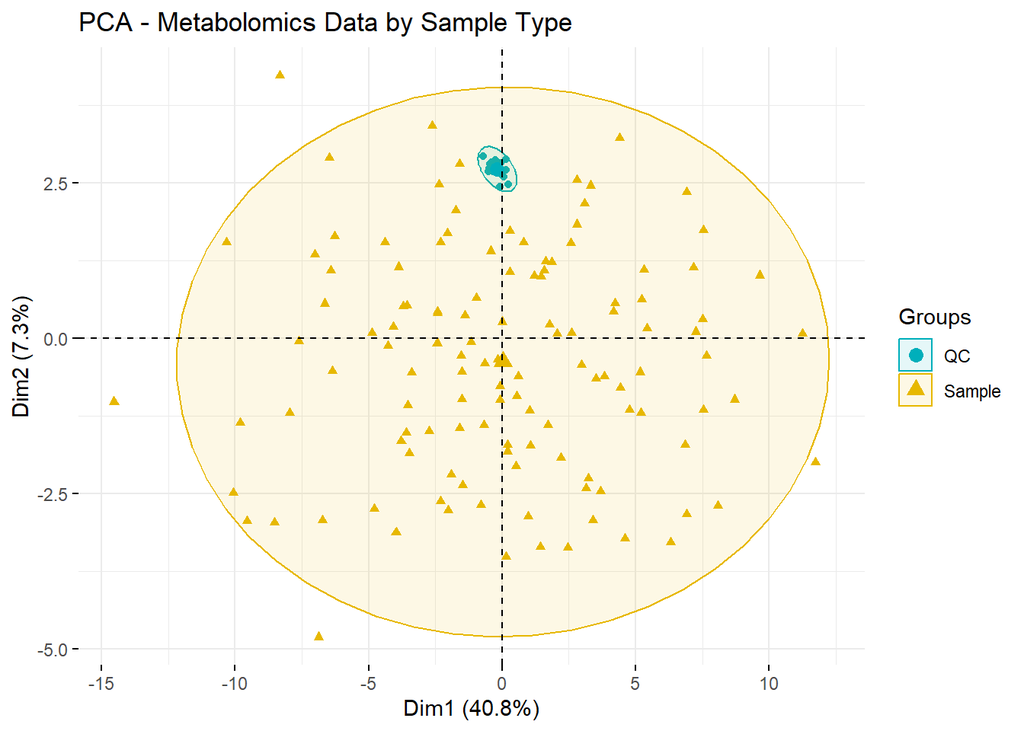

```r
# Asegurarse de que SampleType es un factor y coincide con las filas de scaled_data
sample_type <- factor(data_filtered$SampleType)

# Ejecutar PCA
pca_result <- PCA(scaled_data, graph = FALSE)

# Visualizar PCA
fviz_pca_ind(pca_result,
             label = "none",
             habillage = sample_type,
             palette = c("#00AFBB", "#E7B800"),
             addEllipses = TRUE,
             title = "PCA - Metabolomics Data by Sample Type")
```

Interpretando el resultado del análisis PCA a partir del gráfico, se puede observar que las muestras de control de calidad (en verde azulado) están muy agrupadas, lo que indica de que estas muestras son consistentes y tienen baja variabilidad. Esto sugiere que el proceso de control de calidad ha sido estable y que estas muestras son fiables. Las otras muestras (en amarillo) están más dispersas, lo que es habitual ya que muestras biológicas o de pacientes suelen mostrar una mayor variabilidad.

##### Gráfico de dispersión

Voy a realizar también un gráfico de dispersión, para visualizar cuánta varianza explica cada componente principal, lo que permitiría decidir el número óptimo de componentes para el análisis.

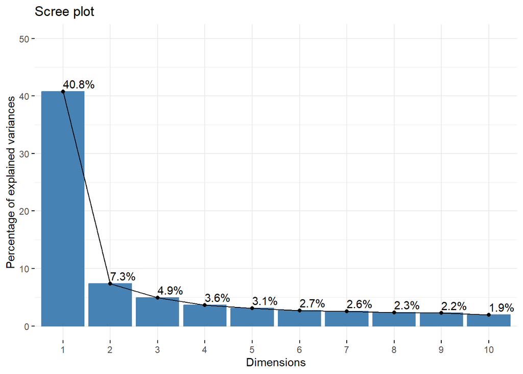

```r
fviz_eig(pca_result, addlabels = TRUE, ylim = c(0, 50))
```

##### Contribuciones de las variables al ACP (gráfico de carga)

También podemos examinar las contribuciones de cada metabolito a los componentes principales:

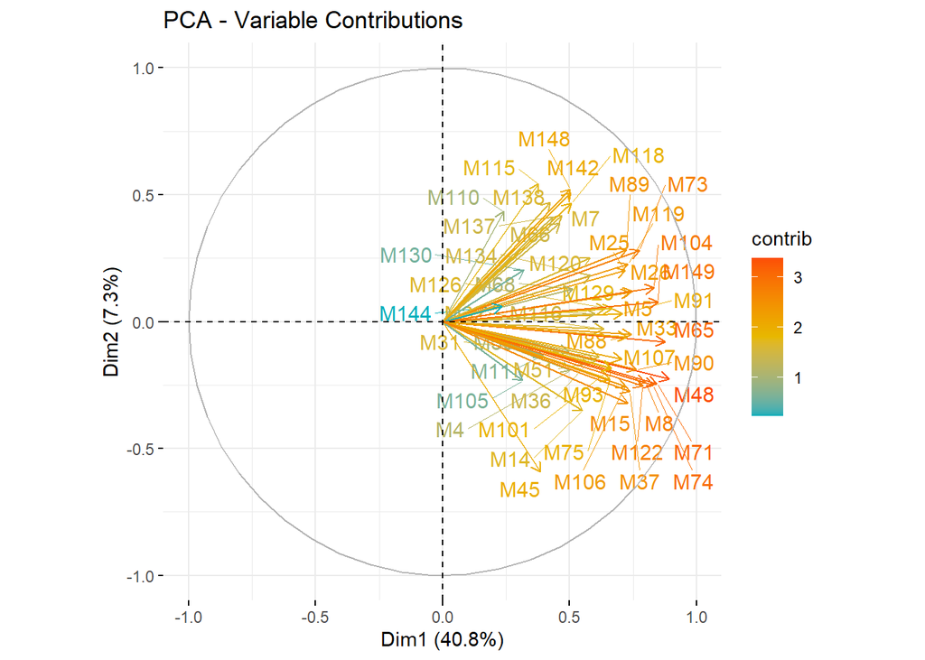

```r
fviz_pca_var(pca_result, col.var = "contrib",
             gradient.cols = c("#00AFBB", "#E7B800", "#FC4E07"),
             repel = TRUE, title = "PCA - Variable Contributions")
```

Este gráfico muestra las contribuciones de cada metabolito (etiquetado como M5, M7,etc.) a los dos primeros componentes principales (PC1 y PC2). El gradiente de color indica el nivel de contribución: el color naranja-rojo indica las contribuciones más altas y el azul-verde las más bajas. Las flechas más largas pueden interpretarse como metabolitos que tienen una mayor influencia en la varianza explicada por PC1 o PC2.

#### Paso 5: Análisis discriminante de mínimos cuadrados parciales (PLS-DA)

Para realizar el PLS-DA, se puede emplear el paquete `mixOmics` de R:

```r
library(mixOmics)
```

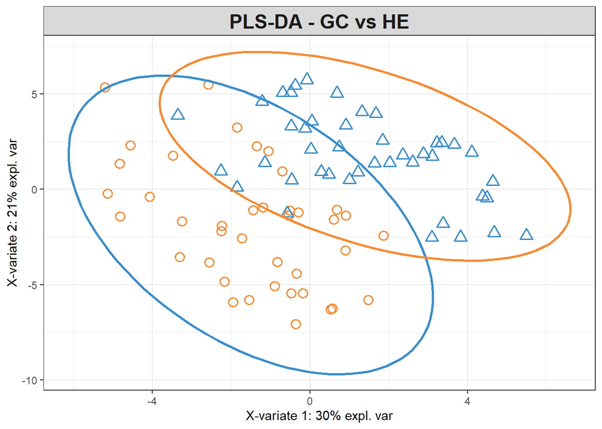

```r
gc_he_data <- subset(data_filtered, Class %in% c("GC", "HE"))

# Configurar datos y etiquetas para PLS-DA
X <- as.matrix(scaled_data[data_filtered$Class %in% c("GC", "HE"), peaklist])
Y <- factor(gc_he_data$Class, levels = c("HE", "GC"))

# Ejecutar PLS-DA con dos componentes
plsda_result <- plsda(X, Y, ncomp = 2)

# Visualizar los resultados PLS-DA
plotIndiv(plsda_result,
          ind.names = FALSE,
          group = Y,
          ellipse = TRUE,
          title = "PLS-DA - GC vs HE")
```

En conclusión, el análisis PLS-DA sugiere que existen diferencias discernibles entre los grupos «GC» y «HE», ya que en general están separados a lo largo de los ejes X-variate 1 y X-variate 2. Sin embargo, el solapamiento entre las elipses de confianza sugiere que, aunque existe cierta capacidad para diferenciar entre los grupos, la separación puede no ser lo suficientemente fuerte como para clasificar todas las muestras con precisión. Una investigación más profunda sobre componentes o variables adicionales podría ayudar a afinar la separación o a comprender las fuentes de solapamiento entre estos grupos.

#### Paso 6: Importancia de las características (puntuaciones VIP)

Para evaluar la importancia de las características en el modelo PLS-DA, se calculan las puntuaciones de Proyección (VIP), que destacan los metabolitos que más contribuyen al poder de discriminación del modelo.

```r
# Calcular VIP scores
vip_scores <- vip(plsda_result)

# Extraer las mejores características basandonos en las puntuaciones VIP
top_features <- vip_scores[vip_scores > 1]
top_features
```

```
##  [1] 1.470874 1.572669 1.042500 1.233289 1.650796 2.393531 1.335761 1.398866
##  [9] 1.889660 1.068166 1.199877 1.046430 2.200871 2.905778 1.735128 1.043777
## [17] 1.076468 1.501813 1.160102 1.459533 1.046216 1.545359 1.248334 1.033389
## [25] 1.020754 1.745231 1.055366 1.039453 1.018713 1.385122 1.605903 2.149781
## [33] 1.268851
```

Para comprender a qué metabolitos corresponden estas puntuaciones, deberíamos asignarlas a los metabolitos específicos (variables) del conjunto de datos. Esto se puede hacer asociando las puntuaciones VIP con los nombres de las características en la lista `Peak`. sin embargo, yo no he podido llegar más lejos en el análisis exploratorio.

## Discusión y limitaciones y conclusiones del estudio

Con el análisis realizado hemos podido observar cómo están estructurados los datos y se puede obtener una idea de cómo se distribuyen, así como las contribuciones de cada metabolito a los componentes principales. Sin embargo, es necesario un análisis más extenso para poder comparar las diferencias en los perfiles entre individuos diagnosticados con cáncer gástrico o pacientes sanos.

## Dirección del repositorio github

A través del siguiente link se puede acceder a mi repositorio de github: BASTERO-Acha-Irati-PEC1